# Assignment 3

Zoe Iacovino

9/20/2020

```r
library(tidyverse)
library(ggplot2)
library(ggthemes)
library (ggmosaic)
mfa<- read.csv("2017 ACS Family Assistance Household.csv")
```

# Relationships between Variables

Because the dataframe I made in [Assignment 1](https://ses-5215-f2020.github.io/ziacovino-quant/Iacovino_Assignment_1_Final.html) was a mix of person and household level analysis, I aggregated the person level data that I could, which meant getting rid of the sex and race variables. If I have time to figure out how to code a majority race of household variable I will–but for now my variables are now:

```r
head(mfa)
```

```
##   X KIDS SNAP    FINC NPL      AGE FERH
## 1 1    1   No  717500   5 33.80000   No
## 2 2    3   No 1315000   5 25.00000   No
## 3 3    1   No  534400   4 31.00000   No
## 4 4    1   No  137580   3 37.66667   No
## 5 5    2   No 1356000   4 21.25000   No
## 6 6    1  Yes   20000   2 28.50000   No
```

## Correlations

- Age [AGE] on Income [FINC] (this one doesn’t make any sense because AGE is now the average age of the houseshold)
- Age [AGE] on Number of Related Children [KIDS] (same issue)
- Annual Family Income [FINC] on Number of Related Children [KIDS]
- Number of People in Household [NPL] on Age [AGE]
- Number of People in Household [NPL] on Number of Related Children [KIDS]
- Number of People in Household [NPL] on Annual Family Income [FINC]

```r
#Age on Income
correlation_aoi <- cor.test(mfa$AGE, mfa$FINC)

correlation_aoi
```

```
##
##  Pearson's product-moment correlation
##
## data:  mfa$AGE and mfa$FINC
## t = 7.732, df = 7040, p-value = 1.206e-14
## alternative hypothesis: true correlation is not equal to 0
## 95 percent confidence interval:
##  0.06855373 0.11487422
## sample estimates:
##        cor
## 0.09176362
```

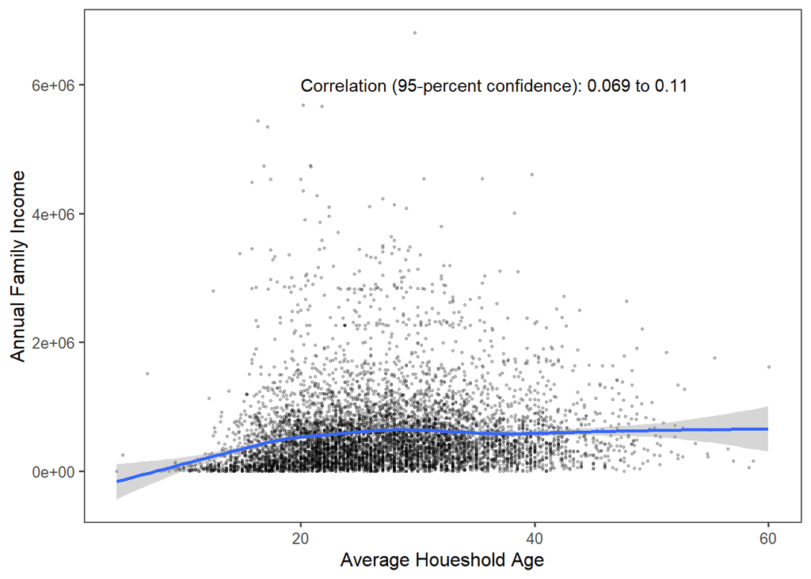

```r
ggplot(mfa, aes(x = AGE, y = FINC)) +
  geom_point(size = 0.5, alpha = 0.25, position = "jitter") +
  geom_smooth() +
  theme_few() +
  scale_x_continuous(name = "Average Houeshold Age") +
  scale_y_continuous(name = "Annual Family Income") +
  annotate(geom = "text", x = 20, y= 6e+06,
           label = paste("Correlation (95-percent confidence):",
                         prettyNum(correlation_aoi$conf.int[1], digits = 2),
                         "to",
                         prettyNum(correlation_aoi$conf.int[2], digits = 2)),
           hjust = 0)
```

With a low p-value and and correlation estimate, I can say the relationship between average household age and income is weak, and that weak relationship is significant.

```r
#Age on Number of Related Children
correlation_aoc <- cor.test(mfa$AGE, mfa$KIDS)

correlation_aoc
```

```
##
##  Pearson's product-moment correlation
##
## data:  mfa$AGE and mfa$KIDS
## t = -43.323, df = 7040, p-value < 2.2e-16
## alternative hypothesis: true correlation is not equal to 0
## 95 percent confidence interval:
##  -0.4770302 -0.4401448
## sample estimates:
##        cor
## -0.4587852
```

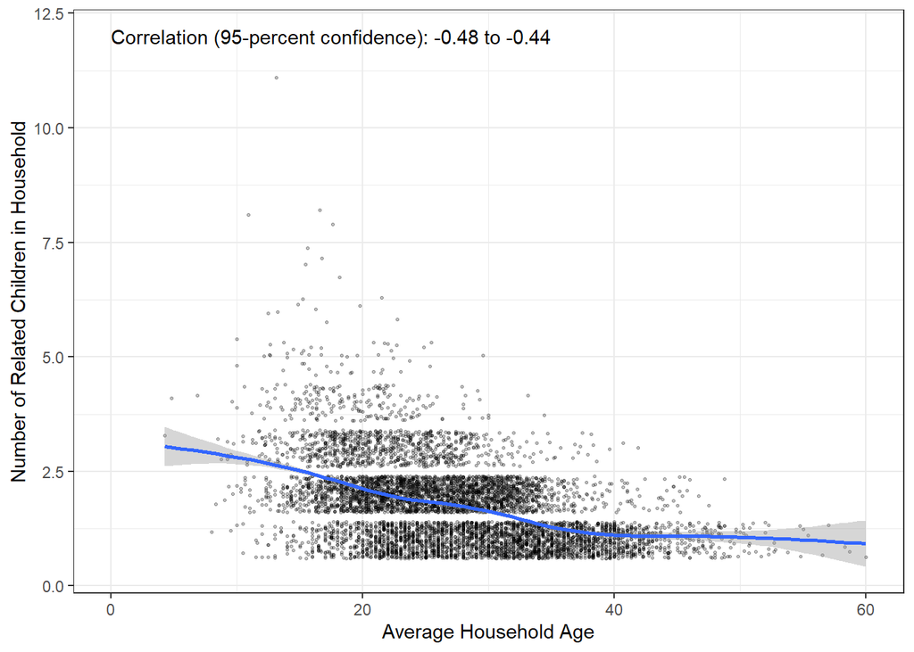

```r
ggplot(mfa, aes(x = AGE, y = KIDS)) +
  geom_point(size = 0.5, alpha = 0.25, position = "jitter") +
  geom_smooth() +
  theme_bw() +
  scale_x_continuous(name = "Average Household Age") +
  scale_y_continuous(name = "Number of Related Children in Household") +
  annotate(geom = "text", x = 0, y = 12,
           label = paste("Correlation (95-percent confidence):",
                         prettyNum(correlation_aoc$conf.int[1], digits = 2),
                         "to",
                         prettyNum(correlation_aoc$conf.int[2], digits = 2)),
           hjust = 0)
```

With a low p-value and a correlation estimate of about -.45, I can say there is a statistically significant relationship between the average age of the household and the number of children that suggests more kids in the household correlates with lower average household. Logically, and mathematically, this makes sense and is not in itself very interesting.

```r
#Annual Family Income on Number of Related Children
correlation_foc <- cor.test(mfa$FINC, mfa$KIDS)

correlation_foc
```

```
##
##  Pearson's product-moment correlation
##
## data:  mfa$FINC and mfa$KIDS
## t = 19.66, df = 7040, p-value < 2.2e-16
## alternative hypothesis: true correlation is not equal to 0
## 95 percent confidence interval:
##  0.2058799 0.2501634
## sample estimates:
##       cor
## 0.2281396
```

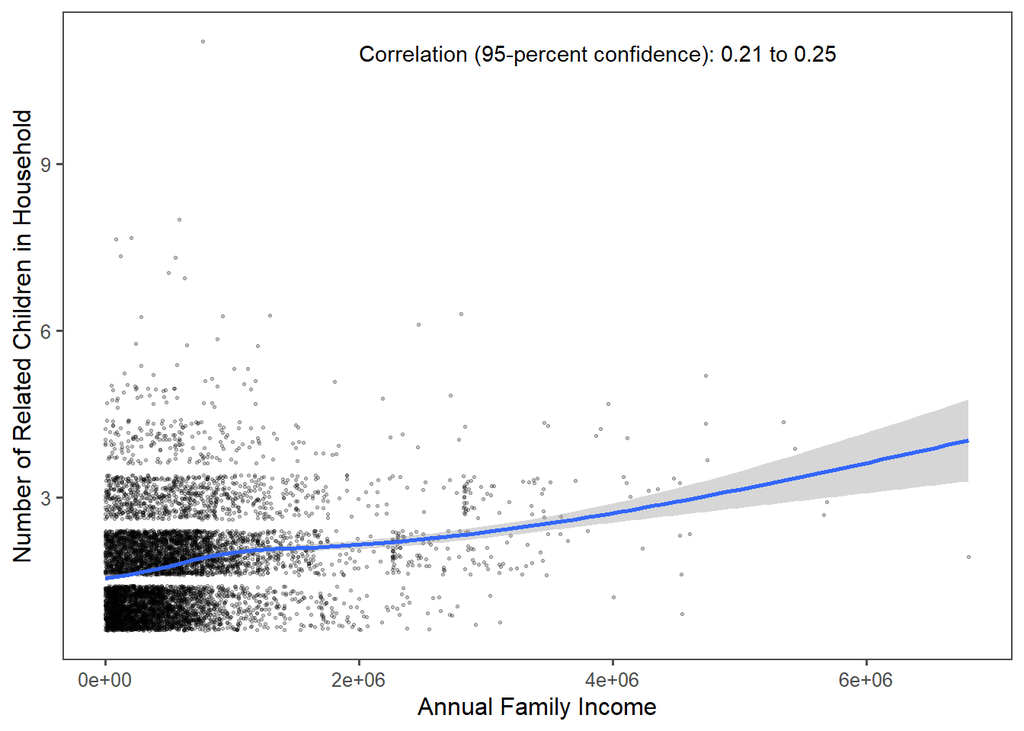

```r
ggplot(mfa, aes(x = FINC, y = KIDS)) +
  geom_point(size = 0.5, alpha = 0.25, position = "jitter") +
  geom_smooth() +
  theme_few() +
  scale_x_continuous(name = "Annual Family Income") +
  scale_y_continuous(name = "Number of Related Children in Household") +
  annotate(geom = "text", x = 2e+06, y = 11,
           label = paste("Correlation (95-percent confidence):",
                         prettyNum(correlation_foc$conf.int[1], digits = 2),
                         "to",
                         prettyNum(correlation_foc$conf.int[2], digits = 2)),
           hjust = 0)
```

The p-value is low, so the relationship is statistically significant. The correlation is about .23, not particularly strong but there is some kind of relationship.

```r
# Number of People on Age
correlation_noa <- cor.test(mfa$NPL, mfa$AGE)

correlation_noa
```

```
##
##  Pearson's product-moment correlation
##
## data:  mfa$NPL and mfa$AGE
## t = -7.6998, df = 7040, p-value = 1.55e-14
## alternative hypothesis: true correlation is not equal to 0
## 95 percent confidence interval:
##  -0.11449642 -0.06817269
## sample estimates:
##         cor
## -0.09138399
```

Unsurprisingly, the number of people in a household does not have a strong correlation with the average age. A low p-value suggests that this weak relationship is statistically significant.

```r
# Number of People on Number of Related Children
correlation_nok <- cor.test(mfa$NPL, mfa$KIDS)

correlation_nok
```

```
##
##  Pearson's product-moment correlation
##
## data:  mfa$NPL and mfa$KIDS
## t = 84.288, df = 7040, p-value < 2.2e-16
## alternative hypothesis: true correlation is not equal to 0
## 95 percent confidence interval:
##  0.6968968 0.7201535
## sample estimates:
##       cor
## 0.7087177
```

Also unsurprisingly, the number of people in the household has a strong correlation with the number of kids in the household. The low p-value suggests this finding is statistically significant.

```r
# Number of People on Annual Family Income
correlation_noi <- cor.test(mfa$NPL, mfa$FINC)

correlation_noi
```

```
##
##  Pearson's product-moment correlation
##
## data:  mfa$NPL and mfa$FINC
## t = 31.914, df = 7040, p-value < 2.2e-16
## alternative hypothesis: true correlation is not equal to 0
## 95 percent confidence interval:
##  0.3349349 0.3757473
## sample estimates:
##       cor
## 0.3555105
```

A positive correlation here suggests what also makes sense logically, more people in the household leads to higher annual household income. There is enough distribution among income levels that the correlation is a little weaker, but the low p-value suggests at least that it is statistically significant.

## Two-Sample T-Tests

- Snap Recipients [SNAP] on Number of Related Children [KIDS]
- New Baby [FERH] on Number of Related Children [KIDS]
- Snap Recipients [SNAP] on Family Income [FINC]
- New Baby [FERH] on Family Income [FINC]
- Snap Recipients [SNAP] on Age [AGE]
- New Baby [FERH] on Age [AGE]
- Snap Recipients [SNAP] on Number of People in House [NPL]
- New Baby [FERH] on Number of People in House [NPL]

```r
#SNAP Recipients on Number of Related Children

difference <- t.test(KIDS ~ SNAP,
                    data = mfa)

difference
```

```
##
##  Welch Two Sample t-test
##
## data:  KIDS by SNAP
## t = -5.7755, df = 1132.4, p-value = 9.905e-09
## alternative hypothesis: true difference in means is not equal to 0
## 95 percent confidence interval:
##  -0.2806429 -0.1383137
## sample estimates:
##  mean in group No mean in group Yes
##          1.739159          1.948637
```

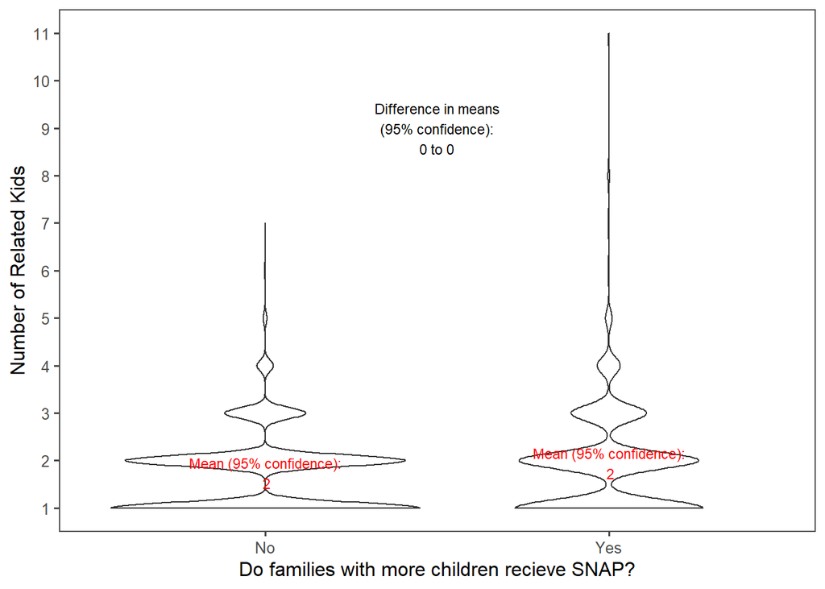

```r
ggplot(mfa, aes(x = SNAP, y = KIDS)) +
  geom_violin() +
  theme_few() +
  scale_x_discrete(name = "Do families with more children recieve SNAP?",
                   labels = c("No", "Yes")) +
  scale_y_continuous(name = "Number of Related Kids",
                     breaks = seq(0, 12, by = 1),
                     labels = paste( prettyNum(seq(0, 12, by = 1)))) +
  annotate(geom = "text", x = 1.5, y = 9, size = 3,
           label = paste("Difference in means\n(95% confidence):\n",
                         prettyNum(abs(difference$conf.int[2]),
                                   digits = 0), " to ",
                         prettyNum(abs(difference$conf.int[1]),
                                   digits = 0),
                         sep = "")) +
  annotate(geom = "text", x = 1, y = difference$estimate[1], size = 3,
                  color = "red",
           label = paste("Mean (95% confidence):\n",
                         prettyNum(difference$estimate[1], digits = 0))) +
  annotate(geom = "text", x = 2, y = difference$estimate[2], size = 3,
           color = "red",
           label = paste("Mean (95% confidence):\n",
                         prettyNum(difference$estimate[2], digits = 0)))
```

```r
#New Baby on Number of Related Children

difference_fok <- t.test(KIDS ~ FERH,
                    data = mfa)

difference
```

```
##
##  Welch Two Sample t-test
##
## data:  KIDS by SNAP
## t = -5.7755, df = 1132.4, p-value = 9.905e-09
## alternative hypothesis: true difference in means is not equal to 0
## 95 percent confidence interval:
##  -0.2806429 -0.1383137
## sample estimates:
##  mean in group No mean in group Yes
##          1.739159          1.948637
```

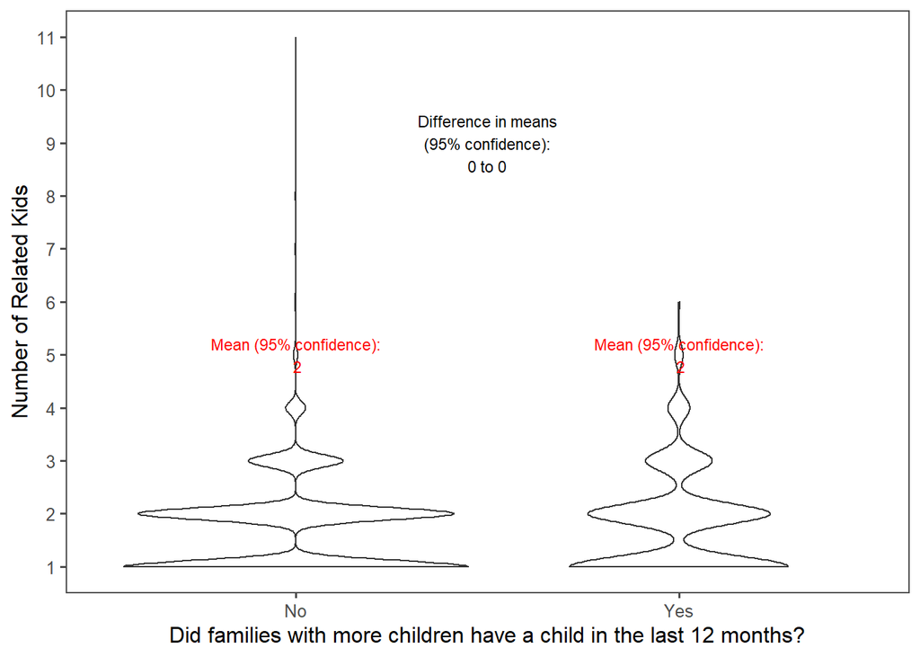

```r
ggplot(mfa, aes(x = FERH, y = KIDS)) +
  geom_violin() +
  theme_few() +
  scale_x_discrete(name = "Did families with more children have a child in the last 12 months?",
                   labels = c("No", "Yes")) +
  scale_y_continuous(name = "Number of Related Kids",
                     breaks = seq(0, 12, by = 1),
                     labels = paste( prettyNum(seq(0, 12, by = 1)))) +
  annotate(geom = "text", x = 1.5, y = 9, size = 3,
           label = paste("Difference in means\n(95% confidence):\n",
                         prettyNum(abs(difference_fok$conf.int[2]),
                                   digits = 0), " to ",
                         prettyNum(abs(difference_fok$conf.int[1]),
                                   digits = 0),
                         sep = "")) +
  annotate(geom = "text", x = 1, y = 5, size = 3,
                  color = "red",
           label = paste("Mean (95% confidence):\n",
                         prettyNum(difference_fok$estimate[1], digits = 0))) +
  annotate(geom = "text", x = 2, y =5, size = 3,
           color = "red",
           label = paste("Mean (95% confidence):\n",
                         prettyNum(difference_fok$estimate[2], digits = 0)))
```

```r
#Snap Recipients on Family Income

difference_soi <- t.test(FINC ~ SNAP, data = mfa)

difference_soi
```

```
##
##  Welch Two Sample t-test
##
## data:  FINC by SNAP
## t = 33.592, df = 2265, p-value < 2.2e-16
## alternative hypothesis: true difference in means is not equal to 0
## 95 percent confidence interval:
##  411469.5 462488.3
## sample estimates:
##  mean in group No mean in group Yes
##          632509.0          195530.1
```

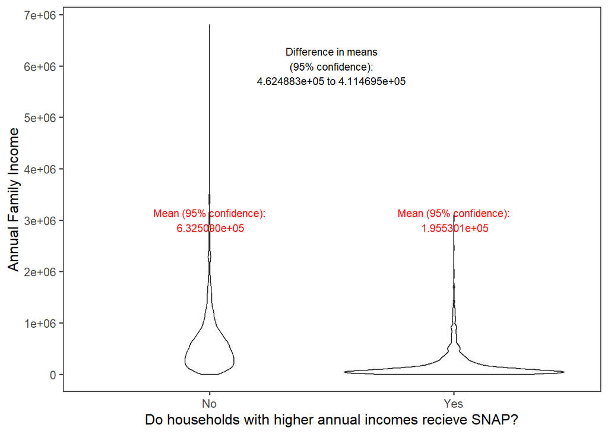

```r
ggplot(mfa, aes(x = SNAP, y = FINC)) +
  geom_violin() +
  theme_few() +
  scale_x_discrete(name = "Do households with higher annual incomes recieve SNAP?",
                   labels = c("No", "Yes")) +
  scale_y_continuous(name = "Annual Family Income",
                     breaks = seq(0, 7000000, by = 1000000),
                     labels = paste( prettyNum(seq(0, 7000000, by = 1000000)))) +
  annotate(geom = "text", x = 1.5, y = 6e+06, size = 3,
           label = paste("Difference in means\n(95% confidence):\n",
                         prettyNum(abs(difference_soi$conf.int[2]),
                                   digits = 0), " to ",
                         prettyNum(abs(difference_soi$conf.int[1]),
                                   digits = 0),
                         sep = "")) +
  annotate(geom = "text", x = 1, y = 3e+06, size = 3,
                  color = "red",
           label = paste("Mean (95% confidence):\n",
                         prettyNum(difference_soi$estimate[1], digits = 0))) +
  annotate(geom = "text", x = 2, y =3e+06, size = 3,
           color = "red",
           label = paste("Mean (95% confidence):\n",
                         prettyNum(difference_soi$estimate[2], digits = 0)))
```

We see some variation when income is taken into account. As we might expect, assistance where eligibility is based income means households recieving SNAP have a lower average income. What is interesting, is the overlap in distribution that suggests folks who are eligible are not recieving.

```r
#New Baby on Family Income

difference_foi <- t.test(FINC ~ FERH, data = mfa)

difference_foi
```

```
##
##  Welch Two Sample t-test
##
## data:  FINC by FERH
## t = 2.5611, df = 829.03, p-value = 0.01061
## alternative hypothesis: true difference in means is not equal to 0
## 95 percent confidence interval:
##   13653.03 103243.22
## sample estimates:
##  mean in group No mean in group Yes
##          578763.2          520315.1
```

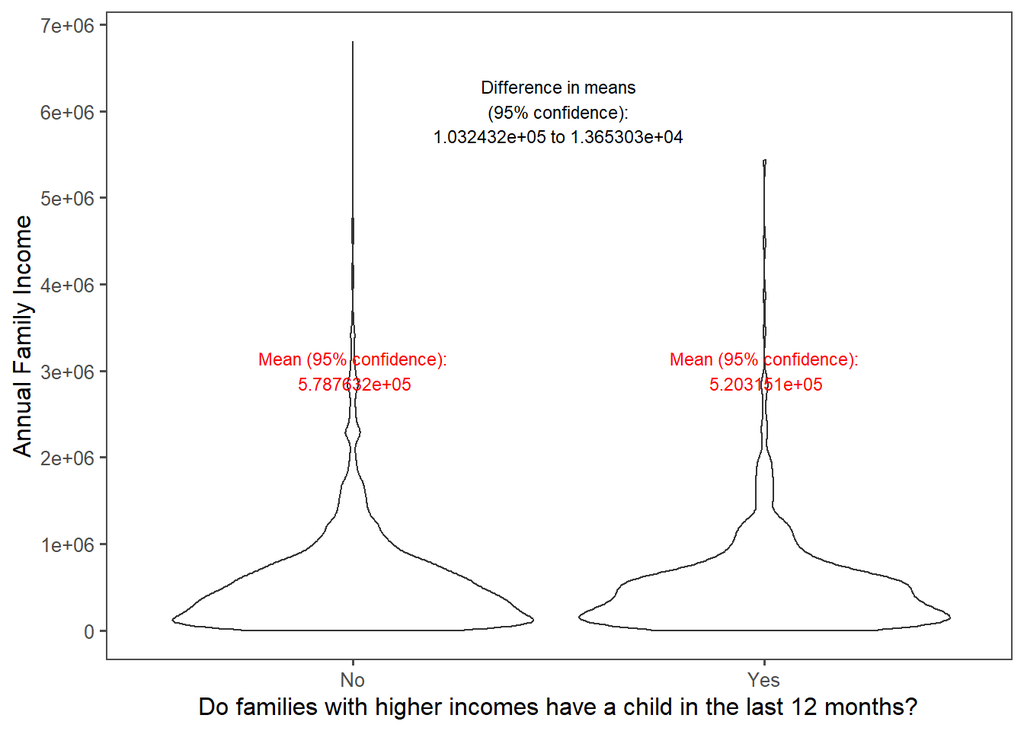

```r
ggplot(mfa, aes(x = FERH, y = FINC)) +
  geom_violin() +
  theme_few() +
  scale_x_discrete(name = "Do families with higher incomes have a child in the last 12 months?",
                   labels = c("No", "Yes")) +
  scale_y_continuous(name = "Annual Family Income",
                     breaks = seq(0, 7000000, by = 1000000),
                     labels = paste( prettyNum(seq(0, 7000000, by = 1000000)))) +
  annotate(geom = "text", x = 1.5, y = 6e+06, size = 3,
           label = paste("Difference in means\n(95% confidence):\n",
                         prettyNum(abs(difference_foi$conf.int[2]),
                                   digits = 0), " to ",
                         prettyNum(abs(difference_foi$conf.int[1]),
                                   digits = 0),
                         sep = "")) +
  annotate(geom = "text", x = 1, y = 3e+06, size = 3,
                  color = "red",
           label = paste("Mean (95% confidence):\n",
                         prettyNum(difference_foi$estimate[1], digits = 0))) +
  annotate(geom = "text", x = 2, y =3e+06, size = 3,
           color = "red",
           label = paste("Mean (95% confidence):\n",
                         prettyNum(difference_foi$estimate[2], digits = 0)))
```

The p-value is not super low, but we might still say the finding is somewhat statistically significant. The two groups look very similar, but the yes group has a slightly lower average income. A possible conclusion could be that income does not really affect whether or not household has a baby.

```r
#SNAP Recipients on Age

difference_soa <- t.test(AGE ~ SNAP, data = mfa)

difference_soa
```

```
##
##  Welch Two Sample t-test
##
## data:  AGE by SNAP
## t = 11.329, df = 1190.4, p-value < 2.2e-16
## alternative hypothesis: true difference in means is not equal to 0
## 95 percent confidence interval:
##  2.777101 3.940435
## sample estimates:
##  mean in group No mean in group Yes
##          27.64114          24.28237
```

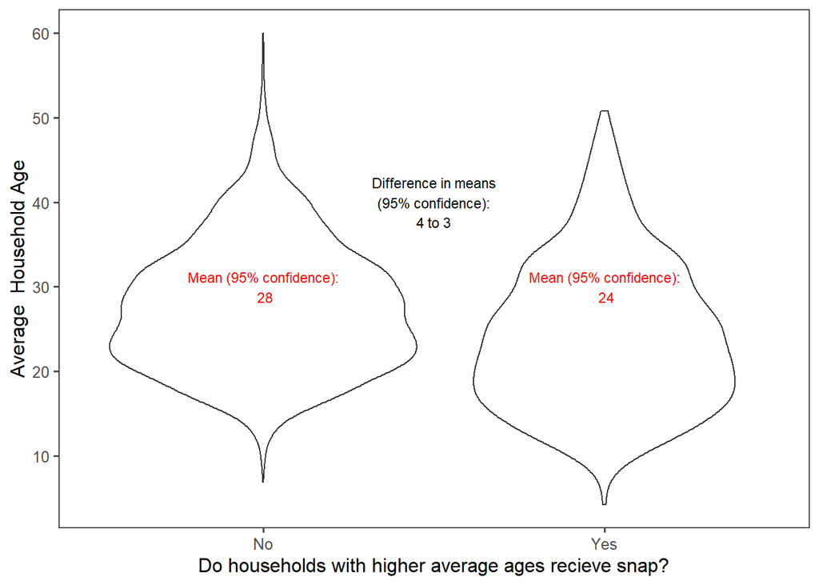

```r
ggplot(mfa, aes(x = SNAP, y = AGE)) +
  geom_violin() +
  theme_few() +
  scale_x_discrete(name = "Do households with higher average ages recieve snap?",
                   labels = c("No", "Yes")) +
  scale_y_continuous(name = "Average  Household Age",
                     breaks = seq(0, 80, by = 10),
                     labels = paste( prettyNum(seq(0, 80, by = 10)))) +
  annotate(geom = "text", x = 1.5, y = 40, size = 3,
           label = paste("Difference in means\n(95% confidence):\n",
                         prettyNum(abs(difference_soa$conf.int[2]),
                                   digits = 0), " to ",
                         prettyNum(abs(difference_soa$conf.int[1]),
                                   digits = 0),
                         sep = "")) +
  annotate(geom = "text", x = 1, y = 30, size = 3,
                  color = "red",
           label = paste("Mean (95% confidence):\n",
                         prettyNum(difference_soa$estimate[1], digits = 0))) +
  annotate(geom = "text", x = 2, y =30, size = 3,
           color = "red",
           label = paste("Mean (95% confidence):\n",
                         prettyNum(difference_soa$estimate[2], digits = 0)))
```

This is interesting, households receiving SNAP are a little younger, and seem to cut off as the household gets older. A confounding aspect of this is households with a baby less than 1 year are going to skew much younger than the rest of population, because my age variable is an average of the household. The p-value is low, so we can assume this finding is statistically significant.

```r
#New Baby on Age

difference_foa <- t.test(AGE ~ FERH, data = mfa)

difference_foa
```

```
##
##  Welch Two Sample t-test
##
## data:  AGE by FERH
## t = 24.407, df = 859.8, p-value < 2.2e-16
## alternative hypothesis: true difference in means is not equal to 0
## 95 percent confidence interval:
##  6.022302 7.075596
## sample estimates:
##  mean in group No mean in group Yes
##          27.79712          21.24817
```

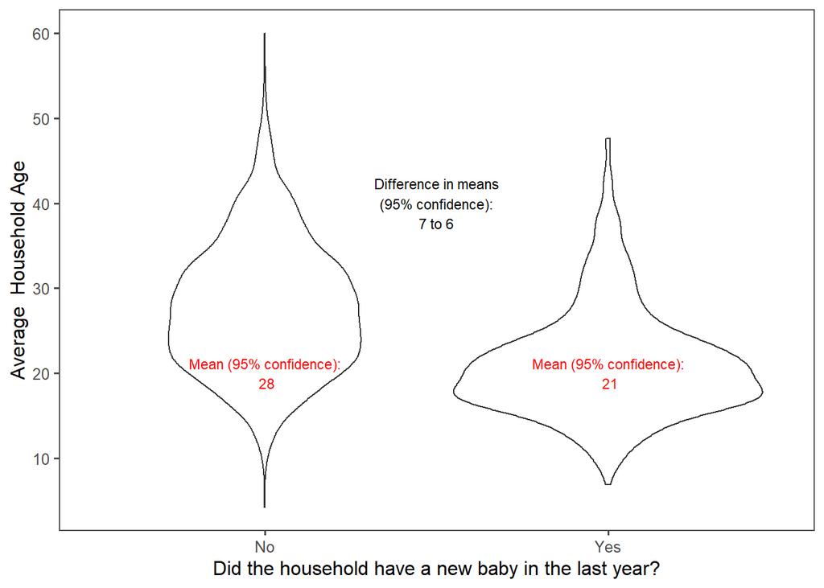

```r
ggplot(mfa, aes(x = FERH, y = AGE)) +
  geom_violin() +
  theme_few() +
  scale_x_discrete(name = "Did the household have a new baby in the last year?",
                   labels = c("No", "Yes")) +
  scale_y_continuous(name = "Average  Household Age",
                     breaks = seq(0, 80, by = 10),
                     labels = paste( prettyNum(seq(0, 80, by = 10)))) +
  annotate(geom = "text", x = 1.5, y = 40, size = 3,
           label = paste("Difference in means\n(95% confidence):\n",
                         prettyNum(abs(difference_foa$conf.int[2]),
                                   digits = 0), " to ",
                         prettyNum(abs(difference_foa$conf.int[1]),
                                   digits = 0),
                         sep = "")) +
  annotate(geom = "text", x = 1, y = 20, size = 3,
                  color = "red",
           label = paste("Mean (95% confidence):\n",
                         prettyNum(difference_foa$estimate[1], digits = 0))) +
  annotate(geom = "text", x = 2, y =20, size = 3,
           color = "red",
           label = paste("Mean (95% confidence):\n",
                         prettyNum(difference_foa$estimate[2], digits = 0)))
```

A low p-value suggests that this is statistically significant: households with a new baby have a lower average age. As with the Age/SNAP analysis, the age cuts off pretty abruptly.

```r
#SNAP on Number of People in House

difference_son <- t.test(NPL ~ SNAP, data = mfa)

difference_son
```

```
##
##  Welch Two Sample t-test
##
## data:  NPL by SNAP
## t = -1.4328, df = 1111.8, p-value = 0.1522
## alternative hypothesis: true difference in means is not equal to 0
## 95 percent confidence interval:
##  -0.17504149  0.02729165
## sample estimates:
##  mean in group No mean in group Yes
##          3.906209          3.980084
```

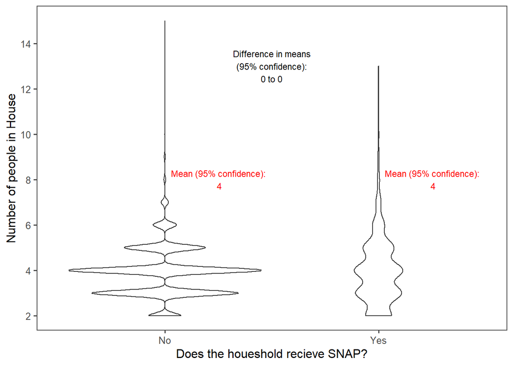

```r
ggplot(mfa, aes(x = SNAP, y = NPL)) +
  geom_violin() +
  theme_few() +
  scale_x_discrete(name = "Does the houeshold recieve SNAP?",
                   labels = c("No", "Yes")) +
  scale_y_continuous(name = "Number of people in House",
                     breaks = seq(0, 20, by = 2),
                     labels = paste( prettyNum(seq(0, 20, by = 2)))) +
  annotate(geom = "text", x = 1.5, y = 13, size = 3,
           label = paste("Difference in means\n(95% confidence):\n",
                         prettyNum(abs(difference_son$conf.int[2]),
                                   digits = 0), " to ",
                         prettyNum(abs(difference_son$conf.int[1]),
                                   digits = 0),
                         sep = "")) +
  annotate(geom = "text", x = 1.25, y = 8, size = 3,
                  color = "red",
           label = paste("Mean (95% confidence):\n",
                         prettyNum(difference_son$estimate[1], digits = 0))) +
  annotate(geom = "text", x = 2.25, y =8, size = 3,
           color = "red",
           label = paste("Mean (95% confidence):\n",
                         prettyNum(difference_son$estimate[2], digits = 0)))
```

Recieving SNAP not only does not seem to have any relationship with the household size, but anything shown here is not very statistically significant. However the graphs look pretty different between SNAP and not, which is interesting.

```r
#New Baby on Number of People in House

difference_fon <- t.test(NPL ~ FERH, data = mfa)

difference_fon
```

```
##
##  Welch Two Sample t-test
##
## data:  NPL by FERH
## t = -4.2194, df = 766.56, p-value = 2.743e-05
## alternative hypothesis: true difference in means is not equal to 0
## 95 percent confidence interval:
##  -0.3247906 -0.1185354
## sample estimates:
##  mean in group No mean in group Yes
##          3.895536          4.117199
```

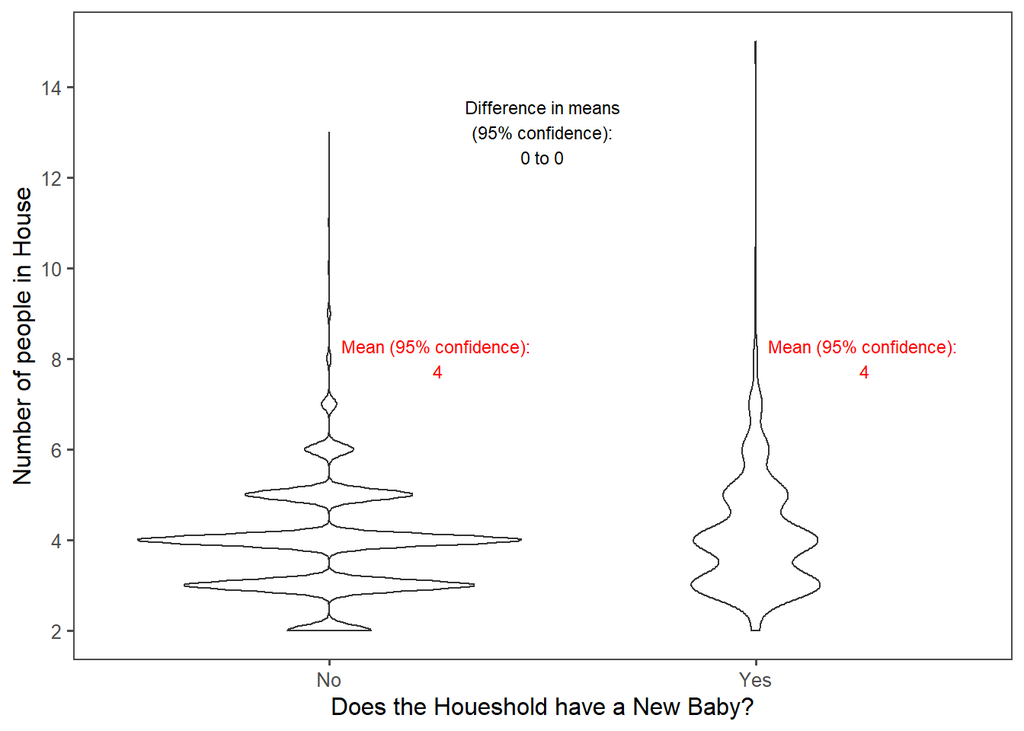

```r
ggplot(mfa, aes(x = FERH, y = NPL)) +
  geom_violin() +
  theme_few() +
  scale_x_discrete(name = "Does the Houeshold have a New Baby?",
                   labels = c("No", "Yes")) +
  scale_y_continuous(name = "Number of people in House",
                     breaks = seq(0, 20, by = 2),
                     labels = paste( prettyNum(seq(0, 20, by = 2)))) +
  annotate(geom = "text", x = 1.5, y = 13, size = 3,
           label = paste("Difference in means\n(95% confidence):\n",
                         prettyNum(abs(difference_fon$conf.int[2]),
                                   digits = 0), " to ",
                         prettyNum(abs(difference_fon$conf.int[1]),
                                   digits = 0),
                         sep = "")) +
  annotate(geom = "text", x = 1.25, y = 8, size = 3,
                  color = "red",
           label = paste("Mean (95% confidence):\n",
                         prettyNum(difference_fon$estimate[1], digits = 0))) +
  annotate(geom = "text", x = 2.25, y =8, size = 3,
           color = "red",
           label = paste("Mean (95% confidence):\n",
                         prettyNum(difference_fon$estimate[2], digits = 0)))
```

The low p-value suggests this finding is statistically significant. Having a child in the last year does not make a huge difference for the average number of people in the house for the population. However, as the chart above, there does seem to be a difference in the distribution of the population.

# ANOVA

None of my categorical variables have more than two levels, so ANOVA is not the best form of analysis for my data. In the interest of practice, I have done SNAP recipients and Number of Related Children as a example.

```r
#SNAP Recipient on Number of Related Children
anova_sok <- aov(KIDS ~ SNAP, data = mfa)

summary(anova_sok)
```

```
##               Df Sum Sq Mean Sq F value   Pr(>F)
## SNAP           1     36   36.19   49.43 2.25e-12 ***
## Residuals   7040   5154    0.73
## ---
## Signif. codes:  0 '***' 0.001 '**' 0.01 '*' 0.05 '.' 0.1 ' ' 1
```

```r
#              Df Sum Sq Mean Sq F value   Pr(>F)
#SNAP           1     36   36.19   49.43 2.25e-12 ***
#Residuals   7040   5154    0.73
#---
#Signif. codes:  0 ‘***’ 0.001 ‘**’ 0.01 ‘*’ 0.05 ‘.’ 0.1 ‘ ’ 1

differences_sok <- TukeyHSD(anova_sok)

as_tibble(cbind(pair = row.names(differences_sok$FS_label),
                differences_sok$FS_label))
```

```
## # A tibble: 0 x 0
```

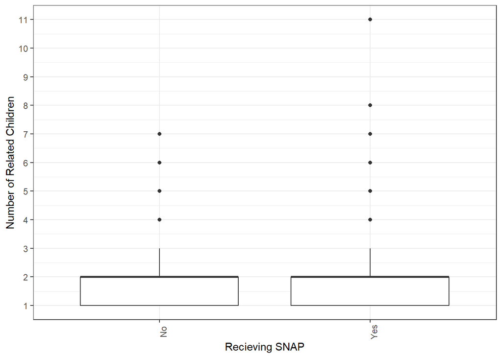

```r
ggplot(mfa, aes(x = SNAP, y = KIDS)) +
  geom_boxplot() +
  theme_bw() +
  theme(axis.text.x = element_text(angle = 90)) +
  scale_x_discrete(name = "Recieving SNAP") +
  scale_y_continuous(name = "Number of Related Children",
                     breaks = seq(0, 12, by = 1),
                     labels = paste(prettyNum(seq(0, 12, by = 1)
                                              )))
```

The result is statistically significant, and it does show pretty clearly that most households only have 1 or 2 children regardless of SNAP. Notably, SNAP recipients do include larger families.

# Chi Squared

```r
#New Baby in last 12 Months on Snap Recipients
chi_sq_fer <- chisq.test(mfa$SNAP, mfa$FERH )

chi_sq_fer
```

```
##
##  Pearson's Chi-squared test with Yates' continuity correction
##
## data:  mfa$SNAP and mfa$FERH
## X-squared = 12.469, df = 1, p-value = 0.0004139
```

```r
chi_sq_fer$observed
```

```
##         mfa$FERH
## mfa$SNAP   No  Yes
##      No  5550  538
##      Yes  835  119
```

```r
chi_sq_fer$expected
```

```
##         mfa$FERH
## mfa$SNAP        No       Yes
##      No  5520.0057 567.99432
##      Yes  864.9943  89.00568
```

The Chi-Squared test suggests that we would see a difference of about 30 households if there were no relationship between the two conditions. Compared to the size of the population examined, that is not very many, and with a p-value that is low but incredibly so, it seems likely there is not a strong correlation between a household having a new baby and recieving food stamps.